# Resistance test in liquid - Static & short term

```r
library(tidyverse)
library(broom)
library(cowplot)
library(here)
library(caTools)
```

# Reduction of Bacterial Growth

Based on method described by Poullain et al. (2008). The evolution of specificity in evolving and coevolving antagonistic interactions between a bacteria and its phage. Evolution: International Journal of Organic Evolution, 62(1), 1-11.

> The reduction in bacterial absorbance “RBG” induced by phage i on bacterial colony j, was calculated as RBGij=[abs630(t= 20) − abs630(t= 0)]ij/[abs630(t= 20) − abs630(t= 0)]controlj. Each cross‐infection was performed in triplicate at the same time. Thus only data corresponding to RBGij < 0.95 were considered in the analyses (positive infection). Data are presented as 1 – RBGi for more clarity.

In this round of the experiment we are looking into the incubation time of a static plate for endpoint assay.

# static plate data

Plot

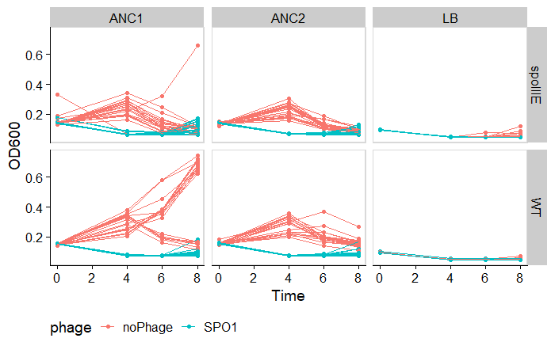

Looks like 4 hours shroud work well

# Edge effect (for no-phage only)

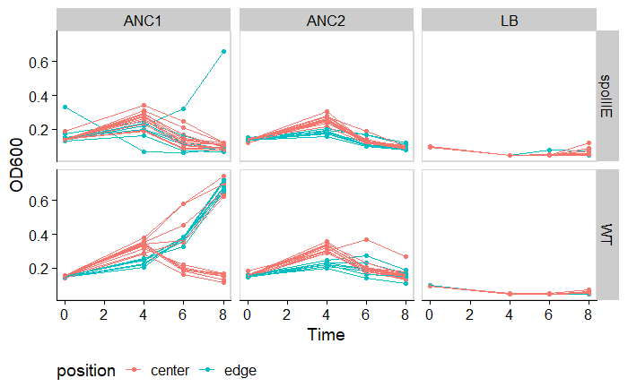

## Looking at the controls (compared with shaken)

```r
pA <-
d.avg%>%
  filter(str_detect(host, "ANC")|str_detect(host, "blank"))%>%
  # filter(Time<Tmax)%>%
  # get first and lat time point within 0:Tmax
    group_by(well) %>%
  arrange(Time) %>%
  filter(row_number()==1 | row_number()==n())%>%
  mutate(Time=ifelse(Time<1,0,2))%>%
      ggplot(aes(x=Time, y=OD600))+
    geom_line(aes(color=phage), size=1)+
    facet_wrap(~host)+
  theme_cowplot()+
    panel_border()+
  theme(legend.position = "bottom",
        axis.text.x = element_blank())+
  ylim(0,1.25)+
  ggtitle("Shaken")

pA2 <-
d.avg%>%
  filter(str_detect(host, "ANC")|str_detect(host, "blank"))%>%
  filter(Time<Tmax)%>%
  # get first and lat time point within 0:Tmax
    group_by(well) %>%
  arrange(Time) %>%
  filter(row_number()==1 | row_number()==n())%>%
  mutate(Time=ifelse(Time<1,0,2))%>%
      ggplot(aes(x=Time, y=OD600))+
    geom_line(aes(color=phage), size=1)+
    facet_wrap(~host)+
  theme_cowplot()+
    panel_border()+
  theme(legend.position = "bottom",
        axis.text.x = element_blank())+
  ylim(0,1.25)+
  ggtitle("Shaken")

pB <- d.static%>%
   mutate(Time = case_when(Time=="T0" ~ 0,
                                Time=="Tend" ~ 1,
                                Time=="Tend.vortex" ~ 2))%>%
  filter(str_detect(host, "ANC")|str_detect(host, "blank"))%>%
  filter(Time!=1)%>%
    ggplot(aes(x=Time, y=OD600))+
    geom_line(aes(color=phage), size=1)+
    facet_wrap(~host)+
  theme_cowplot()+
    panel_border()+
  theme(legend.position = "bottom",
        axis.text.x = element_blank())+
  ylim(0,1.25)+
  ggtitle("Static")

plot_grid(pA, pB)+
  ggsave2(here("plots", "controls_shakenEND.pdf"), width = 10, height = 7)

plot_grid(pA2, pB)+
  ggsave2(here("plots", "controls_shakenBEST.pdf"), width = 10, height = 7)
```

[output not shown]

## Calculate RBG

```r
rbg.static <-
d.static%>%
  #choose static with vortexing
  filter(Time!="Tend.vortex")%>%
  group_by(well) %>%
  mutate(Time=ifelse(Time=="T0","start","end"))%>%
  # pivot to join reads of me well
  pivot_wider(id_cols=c("well", "host", "phage"),names_from = Time, values_from=OD600)%>%
  mutate(dif =end-start)%>%
  # divide dif of each phage by no phage
  ungroup()%>%
  group_by(host) %>%
   mutate(rbg.v = dif / dif[phage == 'noPhage'])%>%
  ungroup()%>%
  filter(phage!="noPhage")%>%
  filter(!str_detect(host, "blank"))%>%
    mutate(phage.time= case_when(phage=="futuure" ~ 1,
                               phage=="current" ~ 0,
                               phage=="past" ~ -1))%>%
  mutate(evo.host= if_else(str_detect(host,"ANC"), "anc","evol"))
```

# show time shift curves

```r
rbg.static.mean <- rbg.static%>%
  filter(!str_detect(host,"ANC"))%>%
  mutate(rbg.v=if_else(rbg.v>1,1,rbg.v))%>%
  group_by(phage.time)%>%
  summarise(rbg.avg=mean(rbg.v),rbg.sd=sd(rbg.v), .groups="drop" )


rbg.static%>%
  filter(evo.host=="evol")%>%
  mutate(rbg.v=if_else(rbg.v>1,1,rbg.v))%>%
  ggplot(aes(x=phage.time, y=rbg.v))+
  geom_line(aes(group=host,color=host), alpha=0.5, size=1)+
  geom_line(data=rbg.static.mean,aes(y=rbg.avg), size=2)+
  geom_pointrange(data=rbg.static.mean,
                  aes(y=rbg.avg,ymin=rbg.avg-rbg.sd,ymax=rbg.avg+rbg.sd),
                  size=1)+
  theme_cowplot()+
  scale_x_continuous(breaks=c(-1,0,1))+
  scale_color_grey()+
  theme(legend.position = "none")
```

[output not shown]